# Preprocess 03: Create Final Analysis Data

2017-05-14

```r
# Load packages
library(tidyverse)
library(data.table)
library(mice)
library(lubridate)
# Load functions
source("../R scripts/functions.R")
```

- Primary exposure of interest:
  - Abuse (Yes / NO)
  - Abuse (4-level)
- Sexual activity in past year is another exposure of special interest. We are only interested in the association between abuse and sexual function among women that were sexually active.
- Outcomes of interest:
  - Sexual satisfaction
  - Sexual frequency satisfaction
- Covariates of interest:
  - Age
  - Race / ethnicity
  - Education
  - Income
  - Marital status
  - Sexual orientation
  - Study component
  - Parity
  - Physical activity
  - Alcohol use
  - Caffeine use
  - Smoking
  - Hormone use
  - Taking SSRIs
  - Quality of life
  - Depression
  - BMI
  - General health
  - Hysterectomy
  - Night sweats
  - Hot flashes
  - Vaginal dryness
  - Urinary incontinence
  - Chronic disease
- The first set of analyses will be cross-sectional, and use only baseline measures

Currently, all 161,808 women are still represented in the data.

```r
# Load data
analysis_09 <- read_rds("../data/analysis_09.rds")
check_data(analysis_09) # 1,432,448 observations and 127 variables
```

```
1,432,448 observations and 127 variables
```

```r
dt <- as.data.table(analysis_09)
```

# Tag baseline observations

Baseline is either each woman’s first response to an abuse question or day 0 if she never responded to either abuse question.

```r
dt[first_ab_obs == TRUE, baseline := TRUE]
dt[abuse_ever == -3 & days == 0, baseline := TRUE]
```

# Subset the variables of interest

```r
dt <- dt[, .(id, days, abuse_d_f, abuse4cat_f, sexactiv_f, satisfied_f, freq_satisfied_f, satfrqsx_f, age,
             age_group_f, race_eth_f, edu4cat_f, inc5cat_f, married_f, sex_f, ctos_f, parity_f, texpwk, alcswk,
             f60caff, smoking_f, horm_f, hormnw_f, ssri_f, lifequal, pshtdep, bmi, good_health_f, hyst_f,
             night_sweats_f, hot_flashes_f, vag_dry_f, incont_f, chronic_disease_f, baseline)]
check_data(dt) # 1,432,448 observations and 35 variables
```

```
1,432,448 observations and 35 variables
```

# Missing sexual activity

Sexual activity in the past year is not being used for modeling. Rather, we will drop women that were not sexually active in the previous year. Multiple imputation is not prediction. And therefore, it would be inappropriate to try to somehow use MI to predict which women were sexually active in the past year, and retain their data for analysis.

> The main message is that we cannot evaluate imputation methods by their ability to re-create the true data, or by their ability to optimize classification accuracy. Imputation is not prediction. van Buuren, Stef (2012-05-14). Flexible Imputation of Missing Data (Chapman & Hall/CRC Interdisciplinary Statistics) (Page 46). Taylor and Francis CRC ebook account. Kindle Edition.

```r
# What is the frequency distribution for sexually active at baseline?
dt[baseline == 1][order(sexactiv_f)][, .(Women = .N), by = sexactiv_f][, Cumsum := cumsum(Women)][
  , Percent := Women / max(Cumsum) * 100][]
```

| sexactiv_f | Women | Cumsum | Percent |
| --- | --- | --- | --- |
| No | 71239 | 71239 | 44.026871 |
| Yes | 83402 | 154641 | 51.543805 |
| NA | 7167 | 161808 | 4.429324 |

```r
71239 + 7167 # 78,406 women have no or NA for sexactive_f at baseline.
```

```
[1] 78406
```

All rows for all 78,406 women that did not report being sexually active in the previous year will be dropped from the data.

```r
# Gather id's with Yes for sexactiv_f at baseline.
keep_ids <- dt[baseline == 1 & sexactiv_f == "Yes", id]
# Keep rows for sexually active women
dt <- dt[id %in% keep_ids]
count_ids(dt$id) # 83,402 unique women
```

```
83,402 unique women
```

How many women report “never having sex” on the sexual orientation question

```r
dt[, length(unique(id)), by = sex_f]
```

| sex_f | V1 |
| --- | --- |
| Sex with a man or with men | 80895 |
| NA | 1368 |
| Sex with both men and women | 863 |
| Have never had sex | 73 |
| Sex with a woman or with women | 203 |

```r
drop_ids <- dt[baseline == 1 & sex_f == "Have never had sex", id]
drop_ids <- which(dt$id %in% drop_ids)
dt <- dt[-drop_ids]
count_ids(dt$id) # 83,402 unique women
```

```
83,329 unique women
```

```r
check_data(dt) # 745,407 observations and 35 variables
```

```
744,745 observations and 35 variables
```

```r
# Clean up
rm(keep_ids, drop_ids)
```

# Missing abuse

How many women are missing abuse (2-level) at baseline?

```r
dt[baseline == 1][order(abuse_d_f)][, .(Women = .N), by = abuse_d_f][, Cumsum := cumsum(Women)][
  , Percent := Women / max(Cumsum) * 100][]
```

| abuse_d_f | Women | Cumsum | Percent |
| --- | --- | --- | --- |
| Abuse not measured | 2 | 2 | 0.002400125 |
| Answered phyab, but not verbab | 115 | 117 | 0.138007176 |
| Answered verbab, but not phyab | 43 | 160 | 0.051602683 |
| No | 73759 | 73919 | 88.515402801 |
| Yes | 9410 | 83329 | 11.292587215 |

How many women are missing abuse (4-level) at baseline?

```r
dt[baseline == 1][order(abuse4cat_f)][, .(Women = .N), by = abuse4cat_f][, Cumsum := cumsum(Women)][
  , Percent := Women / max(Cumsum) * 100][]
```

| abuse4cat_f | Women | Cumsum | Percent |
| --- | --- | --- | --- |
| Physical and verbal abuse | 824 | 824 | 0.988851420 |
| Physical abuse only | 188 | 1012 | 0.225611732 |
| Verbal abuse only | 8374 | 9386 | 10.049322565 |
| Did not experience abuse | 73759 | 83145 | 88.515402801 |
| Can't determine V no P | 60 | 83205 | 0.072003744 |
| Can't determine P no V | 122 | 83327 | 0.146407613 |
| Abuse not measured | 2 | 83329 | 0.002400125 |

```r
# Set alternate codings for missing to NA
dt[, abuse_d_f := if_else(abuse_d_f %in% c("No", "Yes"), abuse_d_f, NA_integer_)]
dt[baseline == 1][order(abuse_d_f)][, .(Women = .N), by = abuse_d_f][, Cumsum := cumsum(Women)][
  , Percent := Women / max(Cumsum) * 100][]
```

| abuse_d_f | Women | Cumsum | Percent |
| --- | --- | --- | --- |
| No | 73759 | 73759 | 88.51540 |
| Yes | 9410 | 83169 | 11.29259 |
| NA | 160 | 83329 | 0.19201 |

```r
# Set alternate codings for missing to NA
keep <- c("Physical and verbal abuse", "Physical abuse only", "Verbal abuse only", "Did not experience abuse")
dt[, abuse4cat_f := if_else(abuse4cat_f %in% keep, abuse4cat_f, NA_integer_)]
dt[baseline == 1][order(abuse4cat_f)][, .(Women = .N), by = abuse4cat_f][, Cumsum := cumsum(Women)][
  , Percent := Women / max(Cumsum) * 100][]
```

| abuse4cat_f | Women | Cumsum | Percent |
| --- | --- | --- | --- |
| Physical and verbal abuse | 824 | 824 | 0.9888514 |
| Physical abuse only | 188 | 1012 | 0.2256117 |
| Verbal abuse only | 8374 | 9386 | 10.0493226 |
| Did not experience abuse | 73759 | 83145 | 88.5154028 |
| NA | 184 | 83329 | 0.2208115 |

```r
# Gather id's without NA for abuse4cat_f at baseline.
ids <- dt[baseline == 1 & !is.na(abuse4cat_f), id]
# Keep rows with non-missing abuse4cat
dt <- dt[id %in% ids]
count_ids(dt$id) # 83,218 unique women
```

```
83,145 unique women
```

```r
83329 - 83145 # 184
```

```
[1] 184
```

184 women were dropped from the data because their abuse status (4-level) could not be determined.

```r
check_data(dt) # 743,094 observations and 35 variables
```

```
743,094 observations and 35 variables
```

```r
# Clean up
rm(keep, ids)
```

# Missing sexual satisfaction

How many women are missing sexual satisfaction at baseline?

```r
dt[baseline == 1][order(satisfied_f)][, .(Women = .N), by = satisfied_f][, Cumsum := cumsum(Women)][
  , Percent := Women / max(Cumsum) * 100][]
```

| satisfied_f | Women | Cumsum | Percent |
| --- | --- | --- | --- |
| No | 18676 | 18676 | 22.461964 |
| Yes | 61208 | 79884 | 73.615972 |
| NA | 3261 | 83145 | 3.922064 |

How many women are missing sexual frequency satisfaction at baseline?

```r
dt[baseline == 1][order(freq_satisfied_f)][, .(Women = .N), by = freq_satisfied_f][, Cumsum := cumsum(Women)][
  , Percent := Women / max(Cumsum) * 100][]
```

| freq_satisfied_f | Women | Cumsum | Percent |
| --- | --- | --- | --- |
| No | 27191 | 27191 | 32.703109 |
| Yes | 52082 | 79273 | 62.639966 |
| NA | 3872 | 83145 | 4.656925 |

Only 4% of women are missing sexual satisfaction at baseline, and only 5% of women are missing sexual frequency satisfaction at baseline. At some point, we may want to come back and impute sexual satisfaction and sexual frequency satisfaction longitudinally. For now, we will impute them from other variables in the data set.

Save progress

```r
analysis_10 <- as_tibble(dt)
write_rds(analysis_10, path = "../data/analysis_10.rds")
```

# Create data subsets for Table 1 (prior to multiple imputation)

```r
# Load data
analysis_10 <- read_rds("../data/analysis_10.rds")
check_data(analysis_10) # 743,756 observations and 34 variables
```

```
743,094 observations and 35 variables
```

```r
count_ids(analysis_10$id) # 83,145 unique women
```

```
83,145 unique women
```

```r
dt <- as.data.table(analysis_10)
```

## Subset baseline observations only

```r
baseline_only <- dt %>% filter(baseline == TRUE)
# Drop the baseline variable
baseline_only$baseline <- NULL
check_data(baseline_only) # 83,218 observations and 34 variables
```

```
83,145 observations and 34 variables
```

## Create subgroups for Table 1 (no, any, verbal only, phys only, both)

```r
no_abuse            <- baseline_only %>% filter(abuse_d_f == "No")
any_abuse           <- baseline_only %>% filter(abuse_d_f == "Yes")
verbal_only         <- baseline_only %>% filter(abuse4cat_f == "Verbal abuse only")
physical_only       <- baseline_only %>% filter(abuse4cat_f == "Physical abuse only")
verbal_and_physical <- baseline_only %>% filter(abuse4cat_f == "Physical and verbal abuse")
# Count total observations
nrow(no_abuse) + nrow(verbal_only) + nrow(physical_only) + nrow(verbal_and_physical) # 83218
```

```
[1] 83145
```

### Data check: group sizes

[output not shown]

## Save subgroup data for Table 1

```r
write_rds(baseline_only, path = "../data/baseline_only.rds")
write_rds(no_abuse, path = "../data/no_abuse.rds")
write_rds(any_abuse, path = "../data/any_abuse.rds")
write_rds(verbal_only, path = "../data/verbal_only.rds")
write_rds(physical_only, path = "../data/physical_only.rds")
write_rds(verbal_and_physical, path = "../data/verbal_and_physical.rds")
```

# Multiple Imputation

```r
# Load data
baseline_only <- read_rds("../data/baseline_only.rds")
check_data(baseline_only) # 83,218 observations and 33 variables
```

```
83,218 observations and 34 variables
```

```r
count_ids(baseline_only$id) # 83,218 unique women
```

```
83,218 unique women
```

```r
dt <- as.data.table(baseline_only)
```

Currently, the data includes information from 83,218 unique women. All women reported sexual activity in the past year. Additionally, each woman’s abuse status can be determined.

## View the number and percent missing for each variable

```r
ini <- mice(dt, maxit = 0)
```

```r
ini$nmis[order(ini$nmis)]
```

```
               id              days         abuse_d_f       abuse4cat_f        sexactiv_f               age
                0                 0                 0                 0                 0                 0
      age_group_f            ctos_f          incont_f        race_eth_f     good_health_f     hot_flashes_f
                0                 0                77               179               212               225
         lifequal            hyst_f         vag_dry_f    night_sweats_f          parity_f         edu4cat_f
              250               294               306               388               455               571
            sex_f           pshtdep            horm_f         married_f       satisfied_f  freq_satisfied_f
             1358              1569              2149              2729              3268              3880
       satfrqsx_f         inc5cat_f            alcswk         smoking_f            texpwk               bmi
             3880              5366              8351              8944             10207             51544
           ssri_f chronic_disease_f           f60caff          hormnw_f
            56627             77053             77570             82447
```

```r
(ini$nmis[order(ini$nmis)] / nrow(dt) * 100) %>% round(1)
```

```
               id              days         abuse_d_f       abuse4cat_f        sexactiv_f               age
              0.0               0.0               0.0               0.0               0.0               0.0
      age_group_f            ctos_f          incont_f        race_eth_f     good_health_f     hot_flashes_f
              0.0               0.0               0.1               0.2               0.3               0.3
         lifequal            hyst_f         vag_dry_f    night_sweats_f          parity_f         edu4cat_f
              0.3               0.4               0.4               0.5               0.5               0.7
            sex_f           pshtdep            horm_f         married_f       satisfied_f  freq_satisfied_f
              1.6               1.9               2.6               3.3               3.9               4.7
       satfrqsx_f         inc5cat_f            alcswk         smoking_f            texpwk               bmi
              4.7               6.4              10.0              10.7              12.3              61.9
           ssri_f chronic_disease_f           f60caff          hormnw_f
             68.0              92.6              93.2              99.1
```

BMI, SSRI, chronic disease, caffeine, and hormone now all have a lot of missing.

## Preparing data for multiple imputation

```r
analysis_10 <- read_rds("../data/analysis_10.rds")
# Drop satfrqsx_f - only needed for table 3.
analysis_10 <- analysis_10 %>% select(-satfrqsx_f)
check_data(analysis_10) # 743,756 observations and 34 variables
```

```
743,756 observations and 34 variables
```

```r
dt <- as.data.table(analysis_10)
```

## Create next closet non-missing value variables

For BMI, SSRI, chronic disease, caffeine, and hormone now, create a second variable that contains the value at the next non-missing observation. I also, need to create a variable that captures the difference in days between observations.

After capturing the longitudinal information in the new variables, I will subset baseline again and perform multiple imputation.

Finally, the newly created variables will be dropped from the data before analysis.

To find the closest measure to baseline, we need to calculate the absolute difference in days between baseline and the day each measure occurred.

```r
dt[baseline == 1, baseline_days := days]
dt[, baseline_days := na.omit(baseline_days)[1], by = id]
dt[, diff_days := abs(days - baseline_days)]
```

```r
# Select variables
imp_vars <- select(dt, bmi, ssri_f, chronic_disease_f, f60caff, hormnw_f) %>% names()
# Get next closest missing values
dt <- get_imp_value(df = dt, imp_vars = imp_vars)
```

## Subset baseline observations only

```r
dt <- dt[baseline == 1]
check_data(dt) # 743,756 observations and 46 variables
```

```
83,218 observations and 46 variables
```

```r
# Clean up
rm(imp_vars)
dt[, c("baseline", "baseline_days", "diff_days") := NULL]
check_data(dt) # 83,218 observations and 46 variables
```

```
83,218 observations and 43 variables
```

## View prop observed and influx / outflux

- pobs = proportion observed
- influx = ranges from 0 to 1. For two variables with the same proportion of missing data, the variable with higher influx is better connected to the observed data, and might thus be easier to impute.
- outflux = ranges from 0 to 1. For two variables with the same proportion of missing data, the variable with higher outflux is better connected to the missing data, and thus potentially more useful for imputing other variables.

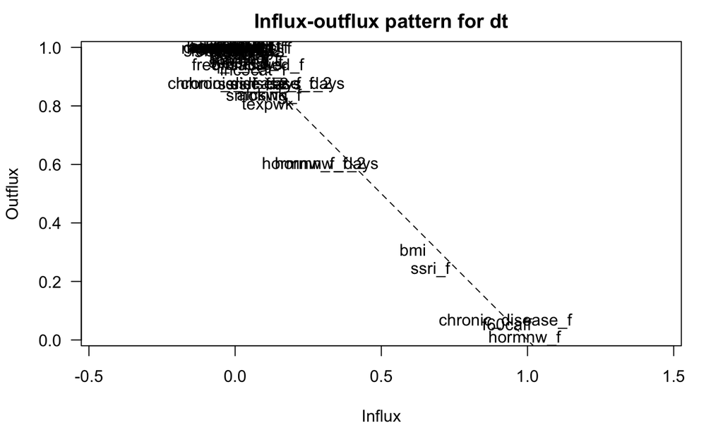

```r
fluxplot(dt)
```

We should also scrutinize the variables at the other end. Variables with high proportions of missing data generally create more problems than they solve. Unless some of these variables are of genuine interest to the investigator, it is best to leave them out. Virtually every dataset contains some parts that could better be removed before imputation. This includes, but is not limited to, uninteresting variables with a high proportion of missing data, variables without a code for the missing data, administrative variables, constant variables, duplicated, recoded or standardized variables, and aggregates and indices of other information.

van Buuren, Stef (2012-05-14). Flexible Imputation of Missing Data (Chapman & Hall/CRC Interdisciplinary Statistics) (Page 175). Taylor and Francis CRC ebook account. Kindle Edition.

## Adjust multiple imputation settings

### View logged events

```r
ini <- mice(dt, m = 0, maxit = 0) # Dry run to view information about the imputation process
ini$loggedEvents
```

|  | it | im | co | dep | meth | out |
| --- | --- | --- | --- | --- | --- | --- |
| 1 | 0 | 0 | 0 |  | constant | sexactiv_f |
| 2 | 0 | 0 | 0 |  | collinear | chronic_disease_f |

Makes sense. Everyone included in the data at this point said yes to sexactiv_f. What is chronic_disease_f colinear with?

```r
dt %>%
  mutate(
    chronic_disease_f   = if_else(is.na(chronic_disease_f), 9, as.numeric(chronic_disease_f)),
    chronic_disease_f_2 = if_else(is.na(chronic_disease_f_2), 9, as.numeric(chronic_disease_f_2))
  ) %>%
  summarise(
    `Count Same` = sum(chronic_disease_f == chronic_disease_f_2),
    `Count Diff` = sum(chronic_disease_f != chronic_disease_f_2)
  )
```

| Count Same | Count Diff |
| --- | --- |
| 12455 | 70763 |

View the current imputation process information

```r
ini
```

```
Multiply imputed data set
Call:
mice(data = dt, m = 0, maxit = 0)
Number of multiple imputations:  0
Missing cells per column:
                    id                   days              abuse_d_f            abuse4cat_f
                     0                      0                      0                      0
            sexactiv_f            satisfied_f       freq_satisfied_f                    age
                     0                   3268                   3880                      0
           age_group_f             race_eth_f              edu4cat_f              inc5cat_f
                     0                    179                    571                   5366
             married_f                  sex_f                 ctos_f               parity_f
                  2729                   1358                      0                    455
                texpwk                 alcswk                f60caff              smoking_f
                 10207                   8351                  77570                   8944
                horm_f               hormnw_f                 ssri_f               lifequal
                  2149                  82447                  56627                    250
               pshtdep                    bmi          good_health_f                 hyst_f
                  1569                  51544                    212                    294
        night_sweats_f          hot_flashes_f              vag_dry_f               incont_f
                   388                    225                    306                     77
     chronic_disease_f                  bmi_2               bmi_days               ssri_f_2
                 77053                   3689                   3689                   7483
           ssri_f_days    chronic_disease_f_2 chronic_disease_f_days              f60caff_2
                  7483                   6626                   6626                    858
          f60caff_days             hormnw_f_2          hormnw_f_days
                   858                  25460                  25460
Imputation methods:
                    id                   days              abuse_d_f            abuse4cat_f
                    ""                     ""                     ""                     ""
            sexactiv_f            satisfied_f       freq_satisfied_f                    age
                    ""               "logreg"               "logreg"                     ""
           age_group_f             race_eth_f              edu4cat_f              inc5cat_f
                    ""              "polyreg"              "polyreg"              "polyreg"
             married_f                  sex_f                 ctos_f               parity_f
              "logreg"              "polyreg"                     ""              "polyreg"
                texpwk                 alcswk                f60caff              smoking_f
                 "pmm"                  "pmm"                  "pmm"              "polyreg"
                horm_f               hormnw_f                 ssri_f               lifequal
              "logreg"               "logreg"               "logreg"                  "pmm"
```

[output cut: 161 more lines]

```
edu4cat_f                       1             1
inc5cat_f                       1             1
married_f                       1             1
sex_f                           1             1
ctos_f                          0             0
parity_f                        1             1
texpwk                          1             1
alcswk                          1             1
f60caff                         1             1
smoking_f                       1             1
horm_f                          1             1
hormnw_f                        1             1
ssri_f                          1             1
 [ reached getOption("max.print") -- omitted 20 rows ]
Random generator seed value:  NA
```

### Adjust prediction matrix

The *rows* of the predictor matrix correspond to the variables being predicted (or not). The *columns* of the predictor matrix correspond to the variables being used to predict.

```r
# Copy the predictor matrix to a new object
pred <- ini$predictorMatrix
# Set cells of the matrix to 0 or 1 as needed, using index [r, c] notation
# All completely observed vars (e.g., age) are not predicted by default (i.e., row of 0's)
pred[, c("id", "age_group_f", "ctos_f")] <- 0 # Don't use these to impute anything
# Adjust imputation for var_days (see description above)
pred[, c("bmi_days", "ssri_f_days", "chronic_disease_f_days", "f60caff_days", "hormnw_f_days")] <- 0
pred["bmi", "bmi_days"]                             <- 1
pred["ssri_f", "ssri_f_days"]                       <- 1
# pred["chronic_disease_f", "chronic_disease_f_days"] <- 1 # Removed for collinearity
pred["f60caff", "f60caff_days"]                     <- 1
pred["hormnw_f", "hormnw_f_days"]                   <- 1
```

### Adjust MI methods

- To prevent vars from being imputed, we need to set the method to missing in addition to adjusting the predictor matrix.
- In this case, everything looks good.

```r
meth
```

```
                    id                   days              abuse_d_f            abuse4cat_f
                    ""                     ""                     ""                     ""
            sexactiv_f            satisfied_f       freq_satisfied_f                    age
                    ""               "logreg"               "logreg"                     ""
           age_group_f             race_eth_f              edu4cat_f              inc5cat_f
                    ""              "polyreg"              "polyreg"              "polyreg"
             married_f                  sex_f                 ctos_f               parity_f
              "logreg"              "polyreg"                     ""              "polyreg"
                texpwk                 alcswk                f60caff              smoking_f
                 "pmm"                  "pmm"                  "pmm"              "polyreg"
                horm_f               hormnw_f                 ssri_f               lifequal
              "logreg"               "logreg"               "logreg"                  "pmm"
               pshtdep                    bmi          good_health_f                 hyst_f
                 "pmm"                  "pmm"               "logreg"               "logreg"
        night_sweats_f          hot_flashes_f              vag_dry_f               incont_f
              "logreg"               "logreg"               "logreg"               "logreg"
     chronic_disease_f                  bmi_2               bmi_days               ssri_f_2
             "polyreg"                  "pmm"                  "pmm"                  "pmm"
           ssri_f_days    chronic_disease_f_2 chronic_disease_f_days              f60caff_2
                 "pmm"                  "pmm"                  "pmm"                  "pmm"
          f60caff_days             hormnw_f_2          hormnw_f_days
                 "pmm"                  "pmm"                  "pmm"
```

## Generate the imputations

```r
start <- now()

imp <- mice(data = dt,
            m = 5,                      # Default - adding for explicitivity
            method = meth,              # Custom method vector created above
            predictorMatrix = pred,     # Custom predictor matrix created above
            seed = 20170511)            # For reproducability

stop <- now()
time <- difftime(stop, start)
```

```r
time # MI took 3.36 hours to run
```

```
Time difference of 3.363606 hours
```

# Save the imputed data

```r
write_rds(imp, path = "../data/imp.rds")
```